# A/B Testing a Call to Action

Simulating Key Ideas from Classical Frequentist Statistics

Author

Yizhen Shi

Published

April 15, 2026

## Introduction

Many websites rely on a call to action (CTA) to encourage visitors to subscribe, create an account, or join a mailing list. On my website, the landing page includes a short message inviting users to sign up for a newsletter. Because even small changes in wording can affect user behavior, choosing the more effective CTA matters.

To study this, I compare two versions of the signup prompt. CTA A reads **“Sign up for our newsletter here!”** while CTA B reads **“Stay up to date by signing up!”**. My goal is to determine which version leads to a higher sign-up rate.

I evaluate the two versions using an A/B test. In an A/B test, visitors are randomly assigned to one of two groups, so one group sees CTA A and the other sees CTA B. Because the assignment is random, any systematic difference in sign-up behavior can be attributed to the CTA wording rather than to pre-existing differences between the users in the two groups.

## The A/B Test as a Statistical Problem

From a statistical perspective, each visitor generates a binary outcome: they either sign up for the newsletter or they do not. This makes the Bernoulli distribution a natural model for individual behavior. If a visitor signs up, I record a 1; otherwise, I record a 0.

Because the text shown to the visitor may influence their behavior, I allow the sign-up probability to differ across the two groups. Let $\pi_A$ denote the probability of signing up after seeing CTA A, and let $\pi_B$ denote the probability of signing up after seeing CTA B.

The quantity of interest is the difference in these probabilities,

$$\theta = \pi_A - \pi_B.$$

If $\theta > 0$, CTA A performs better on average. If $\theta < 0$, CTA B performs better.

To estimate $\theta$, I use the difference in sample means,

$$\hat{\theta} = \bar{X}_A - \bar{X}_B.$$

Since each observation is either 0 or 1, the sample mean in each group is simply the observed sign-up rate. In other words, $\bar{X}_A = \hat{\pi}_A$ and $\bar{X}_B = \hat{\pi}_B$, so the estimator is just the difference in observed conversion rates.

## Simulating Data

In a real experiment, the true sign-up probabilities would be unknown. That is exactly why A/B tests are useful: we collect data in order to learn about those unknown probabilities. For this assignment, however, simulation is useful because it allows me to specify the truth in advance and then examine how well the statistical tools recover it.

I assume that visitors who see CTA A sign up with probability $\pi_A = 0.22$, while visitors who see CTA B sign up with probability $\pi_B = 0.18$. Under this setup, the true treatment effect is

$$\theta = \pi_A - \pi_B = 0.04.$$

I then simulate 1,000 visitors in each group. Each simulated visitor either signs up (1) or does not (0), producing two Bernoulli samples that I use throughout the rest of the analysis.

```python
n = 1000
pi_A = 0.22
pi_B = 0.18

A = np.random.binomial(1, pi_A, n)
B = np.random.binomial(1, pi_B, n)

theta_hat = A.mean() - B.mean()

summary_table = pd.DataFrame({
    "Group": ["CTA A", "CTA B"],
    "Sample Size": [len(A), len(B)],
    "Observed Sign-up Rate": [A.mean(), B.mean()]
})

summary_table["Observed Sign-up Rate"] = summary_table["Observed Sign-up Rate"].round(3)
summary_table
```

|  | Group | Sample Size | Observed Sign-up Rate |
| --- | --- | --- | --- |
| 0 | CTA A | 1000 | 0.225 |
| 1 | CTA B | 1000 | 0.179 |

In this simulated sample, the observed sign-up rate for CTA A is slightly higher than that for CTA B, which is consistent with the true data-generating process. Because the data are random, the estimated difference will not be exactly 0.04 in every simulation, but it should be reasonably close.

## The Law of Large Numbers

The Law of Large Numbers tells us that as the sample size increases, the sample mean tends to move closer to the true population mean. This is one of the main reasons sample averages are so useful in statistics: with enough observations, they become reliable summaries of the underlying process.

In this setting, that idea applies directly to the estimator $\hat{\theta} = \bar{X}_A - \bar{X}_B$. If the two group means each stabilize around their true probabilities, then their difference should also stabilize around the true effect $\theta = 0.04$.

To illustrate this, I compute the element-wise differences between the simulated A and B outcomes and then take the cumulative average. This shows how the estimate behaves as more and more observations are included.

```python
diff = A - B
running_mean = np.cumsum(diff) / np.arange(1, len(diff) + 1)

running_df = pd.DataFrame({
    "Observation": np.arange(1, len(diff) + 1),
    "Running Mean": running_mean
})

running_df.head()
```

|  | Observation | Running Mean |
| --- | --- | --- |
| 0 | 1 | 1.000000 |
| 1 | 2 | 0.500000 |
| 2 | 3 | 0.333333 |
| 3 | 4 | 0.000000 |
| 4 | 5 | -0.200000 |

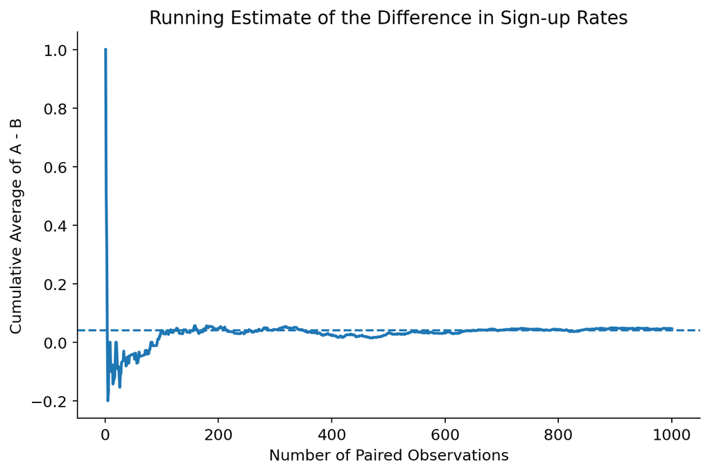

The plot is quite noisy at the beginning because very small samples are heavily influenced by random variation. After more observations accumulate, the running estimate becomes much more stable and begins to settle near the true value of 0.04. This is exactly the behavior predicted by the Law of Large Numbers.

The key takeaway is not that the estimate becomes perfect, but that larger samples make it more dependable. In practice, this is why A/B tests with very small sample sizes can be misleading, while larger experiments tend to produce more credible comparisons.

## Bootstrap Standard Errors

A point estimate is useful, but it is not enough by itself. We also want to know how precise that estimate is. In other words, how much would the estimated difference change if the experiment were repeated with a different random sample of visitors?

The bootstrap provides a practical way to answer that question. Instead of relying entirely on a closed-form formula, I repeatedly resample from the observed data with replacement. For each bootstrap resample, I recompute the statistic of interest. The spread of those bootstrap estimates tells us how variable the estimator is, and the standard deviation of the bootstrap distribution gives an estimated standard error.

```python
boot_thetas = []

for _ in range(1000):
    A_star = np.random.choice(A, size=n, replace=True)
    B_star = np.random.choice(B, size=n, replace=True)
    boot_thetas.append(A_star.mean() - B_star.mean())

boot_thetas = np.array(boot_thetas)
boot_se = boot_thetas.std(ddof=1)

piA_hat = A.mean()
piB_hat = B.mean()

analytical_se = np.sqrt(
    piA_hat * (1 - piA_hat) / n +
    piB_hat * (1 - piB_hat) / n
)

ci_lower = theta_hat - 1.96 * boot_se
ci_upper = theta_hat + 1.96 * boot_se

se_table = pd.DataFrame({
    "Quantity": [
        "Estimated Difference",
        "Bootstrap SE",
        "Analytical SE",
        "95% CI Lower",
        "95% CI Upper"
    ],
    "Value": [theta_hat, boot_se, analytical_se, ci_lower, ci_upper]
})

se_table["Value"] = se_table["Value"].round(4)
se_table
```

|  | Quantity | Value |
| --- | --- | --- |
| 0 | Estimated Difference | 0.0460 |
| 1 | Bootstrap SE | 0.0174 |
| 2 | Analytical SE | 0.0179 |
| 3 | 95% CI Lower | 0.0120 |
| 4 | 95% CI Upper | 0.0800 |

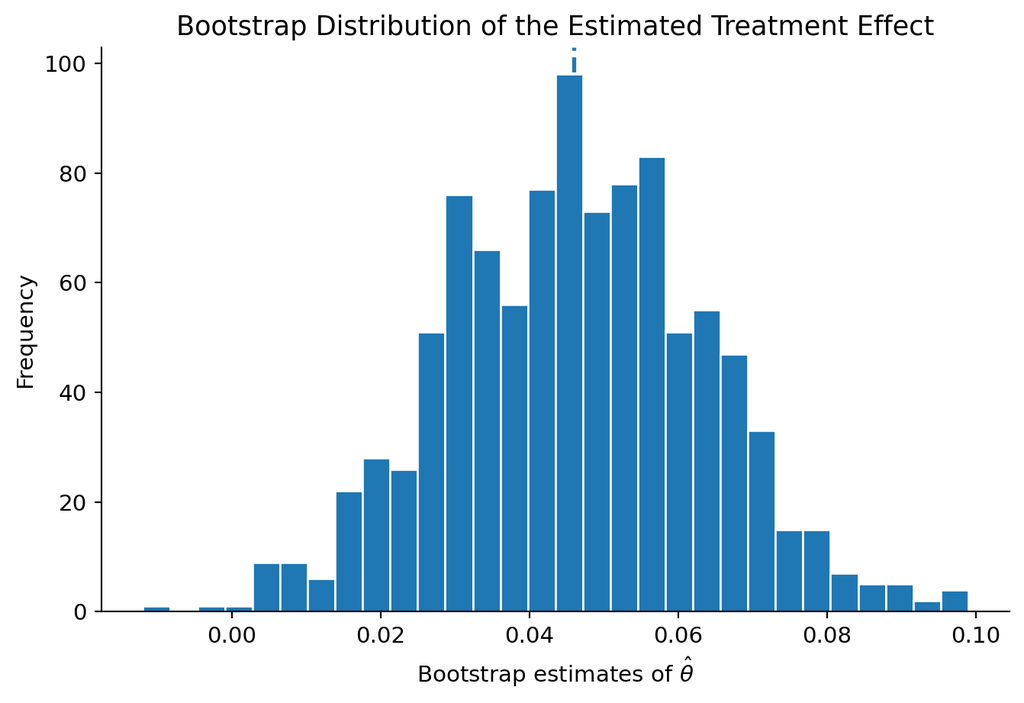

The bootstrap standard error and the analytical standard error are very similar, which is reassuring. That similarity suggests that the analytical formula is working well here, but it also shows that the bootstrap is able to recover the same level of uncertainty using only resampling.

Using the bootstrap standard error, I construct a 95% confidence interval for $\theta$. This interval gives a range of values that are plausible for the true difference in sign-up rates. If the interval excludes zero, that is evidence that the two CTAs may genuinely differ in performance rather than appearing different only because of sampling noise.

The Central Limit Theorem (CLT) is one of the central ideas behind classical inference. It states that, under fairly general conditions, the sampling distribution of a sample mean becomes approximately Normal as the sample size increases. Since my estimator is a difference in sample means, the same idea applies here as well.

This result matters because it allows us to approximate the distribution of $\hat{\theta}$ using a Normal distribution, which in turn makes confidence intervals and hypothesis tests possible.

To illustrate the CLT, I repeatedly simulate the estimator $\hat{\theta}$ for four different sample sizes: $n \in \{25, 50, 100, 500\}$. For each sample size, I generate 1,000 separate estimates and examine the resulting histograms.

```python
sample_sizes = [25, 50, 100, 500]
sampling_results = {}

for n_s in sample_sizes:
    thetas = []
    for _ in range(1000):
        A_s = np.random.binomial(1, pi_A, n_s)
        B_s = np.random.binomial(1, pi_B, n_s)
        thetas.append(A_s.mean() - B_s.mean())
    sampling_results[n_s] = np.array(thetas)

pd.DataFrame({
    "Sample Size": sample_sizes,
    "Mean of Estimates": [sampling_results[s].mean() for s in sample_sizes],
    "SD of Estimates": [sampling_results[s].std(ddof=1) for s in sample_sizes]
}).round(4)
```

|  | Sample Size | Mean of Estimates | SD of Estimates |
| --- | --- | --- | --- |
| 0 | 25 | 0.0379 | 0.1112 |
| 1 | 50 | 0.0370 | 0.0784 |
| 2 | 100 | 0.0393 | 0.0580 |
| 3 | 500 | 0.0399 | 0.0261 |

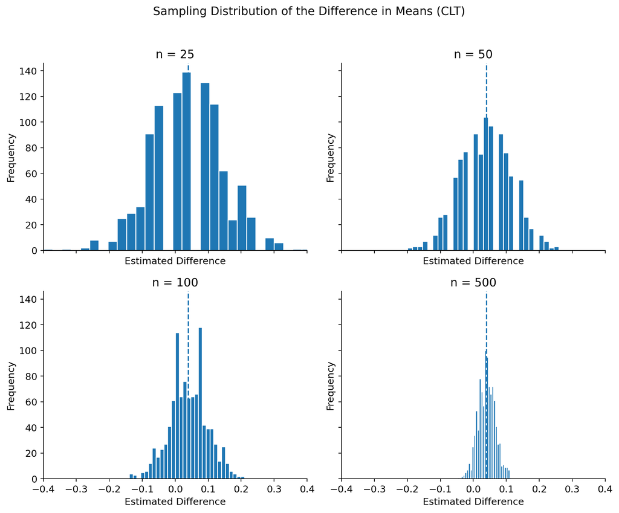

For small sample sizes, the distribution of $\hat{\theta}$ appears rough and somewhat irregular. As the sample size increases, the histogram becomes smoother, more symmetric, and more bell-shaped. This is exactly what the Central Limit Theorem predicts.

The key point is that the underlying data are still Bernoulli, not Normal. What becomes approximately Normal is the *sampling distribution of the estimator*. That is what makes large-sample inference possible in this setting.

## Hypothesis Testing

Now that we have seen why $\hat{\theta}$ behaves well in large samples, we can use that result to perform a formal hypothesis test. The null hypothesis is

$$H_0: \theta = 0,$$

which says that the two CTAs have the same true sign-up rate. The alternative hypothesis is

$$H_1: \theta \neq 0,$$

which says that the sign-up rates differ.

To test the null, I standardize the estimated treatment effect using its estimated standard error:

$$z = \frac{\hat{\theta} - 0}{SE(\hat{\theta})}.$$

The logic is straightforward. By the CLT, the estimator is approximately Normal in large samples. Under the null, its mean is zero. Dividing by its standard deviation therefore produces a statistic that is approximately standard Normal. Once we know the null distribution of the test statistic, we can compute a p-value.

This is often loosely described as a “t-test,” but in this Bernoulli setting the large-sample justification is more naturally a z-test. The distinction is not especially important here in practice, because with large samples the standard Normal and t distributions are extremely similar.

```python
z_stat = theta_hat / analytical_se
p_value = 2 * (1 - norm.cdf(abs(z_stat)))

test_table = pd.DataFrame({
    "Statistic": ["Estimated Difference", "Standard Error", "z-Statistic", "p-Value"],
    "Value": [theta_hat, analytical_se, z_stat, p_value]
})

test_table["Value"] = test_table["Value"].round(4)
test_table
```

|  | Statistic | Value |
| --- | --- | --- |
| 0 | Estimated Difference | 0.0460 |
| 1 | Standard Error | 0.0179 |
| 2 | z-Statistic | 2.5661 |
| 3 | p-Value | 0.0103 |

The test statistic measures how many standard errors the observed estimate lies away from zero. A large absolute value indicates that the observed difference would be unlikely if the null hypothesis were true.

The p-value summarizes that evidence. If it is small, we reject the null hypothesis and conclude that the data provide evidence of a difference between the two CTAs. If it is not small, we do not have strong enough evidence to rule out the possibility that the observed gap was produced by chance alone.

The same comparison can also be written as a simple linear regression. To do this, I stack the two groups into one dataset and define an indicator variable $D_i$ that equals 1 if the visitor saw CTA A and 0 if the visitor saw CTA B. I then estimate

$$Y_i = \beta_0 + \beta_1 D_i + \varepsilon_i.$$

This regression has a very intuitive interpretation. When $D_i = 0$, the expected value of $Y_i$ is just the mean of group B, so $\beta_0$ estimates $\pi_B$. When $D_i = 1$, the expected value is $\beta_0 + \beta_1$, which estimates $\pi_A$. That means $\beta_1$ must equal the difference between the two group means, so it estimates $\theta = \pi_A - \pi_B$.

```python
Y = np.concatenate([A, B])
D = np.concatenate([np.ones(len(A)), np.zeros(len(B))])

reg_df = pd.DataFrame({
    "Y": Y,
    "D": D
})

model = sm.OLS(reg_df["Y"], sm.add_constant(reg_df["D"])).fit()

regression_table = pd.DataFrame({
    "Quantity": [
        "Intercept",
        "Treatment Coefficient",
        "Standard Error of Treatment",
        "t-Statistic",
        "p-Value"
    ],
    "Value": [
        model.params["const"],
        model.params["D"],
        model.bse["D"],
        model.tvalues["D"],
        model.pvalues["D"]
    ]
})

regression_table["Value"] = regression_table["Value"].round(4)
regression_table
```

|  | Quantity | Value |
| --- | --- | --- |
| 0 | Intercept | 0.1790 |
| 1 | Treatment Coefficient | 0.0460 |
| 2 | Standard Error of Treatment | 0.0179 |
| 3 | t-Statistic | 2.5649 |
| 4 | p-Value | 0.0104 |

As expected, the coefficient on the treatment indicator is numerically the same as the difference in sample means computed earlier. The corresponding test statistic and p-value are also essentially the same, aside from minor differences that can arise from how the standard error is estimated.

This equivalence matters because it shows that a simple two-group A/B test is already a regression problem. Once the problem is written in regression form, it becomes easy to add control variables, interactions, or more complicated treatment structures while using the same basic inferential framework.

The coefficient on the treatment indicator matches the difference in sample means computed earlier, confirming the equivalence between the two approaches.

## The Problem with Peeking

Suppose an impatient manager does not want to wait until the experiment is complete. Instead, she checks the results after every 100 visitors per group and plans to stop the experiment as soon as one interim test is statistically significant at the 5% level.

This strategy is tempting, but it breaks the logic of a classical fixed-sample hypothesis test. A single test at $\alpha = 0.05$ has a 5% Type I error rate under the null. But if we repeatedly test the same experiment as the data accumulate, each additional look creates another opportunity to reject by chance. The overall false positive rate can therefore become much larger than 5%.

To demonstrate this, I simulate a world in which the null hypothesis is true. I set $\pi_A = \pi_B = 0.20$, so there is no real treatment effect. For each experiment, I simulate 1,000 observations per group, compute a p-value after every 100 observations, and record whether any of the 10 interim looks is significant. I then repeat the entire experiment 10,000 times.

```python
def peeking_experiment():
    A_null = np.random.binomial(1, 0.20, 1000)
    B_null = np.random.binomial(1, 0.20, 1000)

    for k in range(100, 1001, 100):
        A_k = A_null[:k]
        B_k = B_null[:k]

        theta_k = A_k.mean() - B_k.mean()
        se_k = np.sqrt(
            A_k.mean() * (1 - A_k.mean()) / k +
            B_k.mean() * (1 - B_k.mean()) / k
        )

        if se_k == 0:
            continue

        z_k = theta_k / se_k
        p_k = 2 * (1 - norm.cdf(abs(z_k)))

        if p_k < 0.05:
            return 1
    return 0

peeking_results = np.array([peeking_experiment() for _ in range(10000)])
false_positive_rate = peeking_results.mean()

peeking_table = pd.DataFrame({
    "Quantity": ["Nominal Type I Error", "Empirical Type I Error with Peeking"],
    "Value": [0.05, false_positive_rate]
})

peeking_table["Value"] = peeking_table["Value"].round(4)
peeking_table
```

|  | Quantity | Value |
| --- | --- | --- |
| 0 | Nominal Type I Error | 0.0500 |
| 1 | Empirical Type I Error with Peeking | 0.1952 |

The simulation typically shows that the empirical false positive rate under repeated peeking is well above the nominal 5% level. In other words, even when there is truly no difference between the two CTAs, repeated interim testing makes it much easier to “discover” a winner by chance.

This is the practical danger of peeking. If analysts continuously monitor results and stop as soon as significance appears, they are no longer running a valid 5% hypothesis test. The reported p-value becomes misleading because the testing procedure itself has changed. In real A/B testing, this is why sequential testing methods or pre-registered stopping rules are so important.